# Homework 2

Author

Dana Kilbourne

## Task 1

We are going to return to the table of the top 100 wrestlers: https://www.cagematch.net/?id=2&view=statistics. Specifically, you are going to get the ratings/comments tables for each wrestler.

```python
from bs4 import BeautifulSoup
import requests
import re
import pandas as pd

link = 'https://www.cagematch.net/?id=2&view=statistics'


hot100_req = requests.get(link)

#use beautiful soup and start the same way as number 4 in hw 1
hot100_soup = BeautifulSoup(hot100_req.content, 'html.parser')

all_links = hot100_soup.select('.TCol a')

filtered_links = [link for link in all_links if link['href'].count('&') == 2]
#create empty data frame
df_wrestlers = []

#loop over the wrestlers to get their names and ids so we can use it later to use id in each link
for i in filtered_links:
    wrestler_name = i.text.strip()
    wrestler_href = i['href']

    ID = re.search(r'nr=(\d+)', wrestler_href).group(1)
    #get the wrestler names and IDs
    df_wrestlers.append({
        "Name": wrestler_name,
        "ID": ID,
    })

df_wrestlers = pd.DataFrame(df_wrestlers) #put them in a dataframe

match_comments = []
# "click " each wrestlers based on their ID known as nr in the link and collect the comments and ratings
for i in df_wrestlers['ID']:
    link = f'https://www.cagematch.net/?id=2&nr={i}&page=99'
    hot100_req = requests.get(link)
    hot100_soup = BeautifulSoup(hot100_req.content, 'html.parser')
    num_comments = hot100_soup.select('.CommentHeader')
    wrestler_name = df_wrestlers[df_wrestlers['ID'] == i]['Name'].values[0]
    for com in range(len(num_comments)):
      comments = {'ID': i,
            'Name': wrestler_name,
            'User': hot100_soup.select('.CommentHeader')[com].text,'Comment': hot100_soup.select('.CommentContents')[com].text}
      match_comments.append(comments)

match_comments = pd.DataFrame(match_comments)

#extract all the infomration we need by using regular expressions
match_comments['Date'] = match_comments['User'].str.extract(r'(\d{2}\.\d{2}\.\d{4})')

match_comments['User'] = match_comments['User'].str.replace(r' wrote.*', '', regex=True)

match_comments['Rating']=match_comments['Comment'].str.extract(r'(\[\d+\.\d+\]|\[\d\.\d\])')
match_comments['Rating'] = match_comments['Rating'].str.replace(r'\[(\d+\.\d+|\d\.\d)\]', r'\1', regex=True)

match_comments['Comment'] = match_comments['Comment'].str.replace(r'\[\d+\.\d+\]|\[\d\.\d\]', '', regex=True)

#remove the quotation marks
def remove_first_and_last_quotes(text):
    text = re.sub(r'"', '', text, count=1)
    if text.endswith('"'):
        text = text[:-1]

    return text
match_comments['Comment'] = match_comments['Comment'].apply(remove_first_and_last_quotes)

print(match_comments.head())
```

```
    ID           Name           User  \
0  360  Kenta Kobashi         jesica
1  360  Kenta Kobashi    anarchovamp
2  360  Kenta Kobashi  ZephsPancakes
3  360  Kenta Kobashi            TPG
4  360  Kenta Kobashi      Daniel IW

                                             Comment        Date Rating
0  https://studyx.ai/questions/4ljb19z/is-priceli...  04.02.2025    NaN
1   John Bradshaw famously dubbed himself a wrest...  27.12.2024   10.0
2   I personally slightly edge Misawa over Kobash...  12.12.2024   10.0
3   If I'm being honest, Kobashi's probably one o...  05.12.2024   10.0
4   Known for his devastating chops and iconic mo...  03.12.2024    5.0
```

This shows a data frame of each wrestler with their ratings and comments attached.

```python
#use lang detect to get rid of the german comments

from langdetect import detect

#function to detect language and return True if the comment is not in German
def is_not_german(Comment):
    try:
        return detect(Comment)  #detect and check if it's not German ('de')
    except:
        return True  #if language detection fails, keep the comment
```

```python
match_comments['Comment'] = match_comments['Comment'].str.replace("^https.*", "", regex=True)

#filter out German comments
match_comments['test'] = match_comments['Comment'].apply(is_not_german)
```

```python
#only keep in english comments
df_filtered = match_comments[match_comments['test'] == "en"]
```

## Task 2

Perform any form of sentiment analysis. What is the relationship between a reviewer’s sentiment and their rating?

```
Correlation between ratings and comment sentiment: 0.28724125754884033
```

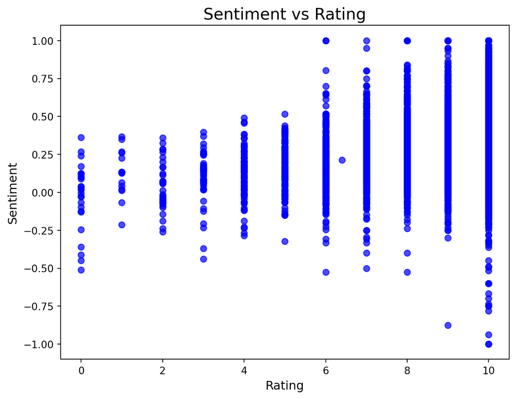

```python
#use text blob

#print(match_comments.dtypes)

#transform the rating to numeric in order to graph
df_filtered['Rating'] = pd.to_numeric(df_filtered['Rating'])

from textblob import TextBlob

#create a function to get the sentiment
def get_sentiment(text):
    return TextBlob(text).sentiment.polarity

#apply the sentiment analysis to each comment
df_filtered['Sentiment'] = df_filtered['Comment'].apply(get_sentiment)

#correlation between ratings and sentiment
correlation = df_filtered['Rating'].corr(df_filtered['Sentiment'])
print(f"Correlation between ratings and comment sentiment: {correlation}")



import matplotlib.pyplot as plt



#scatter plot of Sentiment vs Rating
plt.figure(figsize=(8, 6))
plt.scatter(df_filtered['Rating'], df_filtered['Sentiment'], color='blue', alpha=0.7)

# add labels
plt.title('Sentiment vs Rating', fontsize=16)
plt.xlabel('Rating', fontsize=12)
plt.ylabel('Sentiment', fontsize=12)

#show the plot
plt.show()
```

## Task 3

Perform any type of topic modeling on the comments. What are the main topics of the comments? How can you use those topics to understand what people value?

```python
import sklearn
from sklearn.feature_extraction.text import TfidfVectorizer
from sklearn.decomposition import LatentDirichletAllocation
import re

# function to remove names from comments based on the 'names' column
def remove_names_from_comments(df_filtered):
    # take out the 'names' column and split them into a list
    names = df_filtered['Name'].split(' ')  #split by a space

    #remove the names from the comment
    cleaned_comment = df_filtered['Comment']

    for Name in names:
        #use regex to remove both first and last names (word boundary \b ensures we match whole names)
        cleaned_comment = re.sub(r'\b' + re.escape(Name) + r'\b', '', cleaned_comment)

    return cleaned_comment

# Apply the function to remove names from the 'comments' column
df_filtered['cleaned_comments'] = df_filtered.apply(remove_names_from_comments, axis=1)

# Print the DataFrame with cleaned comments
print(df_filtered[['Comment', 'cleaned_comments']].head())

###find the main topics in the comments section###

# preprocess and vectorize the comments using TF-IDF
vectorizer = TfidfVectorizer(stop_words='english')  # remove stopwords like 'the', 'and', etc.
X = vectorizer.fit_transform(df_filtered['Comment'])

# apply LDA to extract topics
lda = LatentDirichletAllocation(n_components=3, random_state=42)  #extract 3 topics
lda.fit(X)

# show the top words for each topic
n_top_words = 10  # Number of top words to display for each topic
feature_names = vectorizer.get_feature_names_out()

for topic_idx, topic in enumerate(lda.components_):
    print(f"Topic #{topic_idx + 1}:")
    print(" ".join([feature_names[i] for i in topic.argsort()[:-n_top_words - 1:-1]]))





#  Visualize the topics
# import numpy as np
#
# # Generate the topic-word distribution matrix
# topic_word_distribution = lda.components_
```

```
                                             Comment  \
1   John Bradshaw famously dubbed himself a wrest...
2   I personally slightly edge Misawa over Kobash...
3   If I'm being honest, Kobashi's probably one o...
4   Known for his devastating chops and iconic mo...
5  Kobashi was my first introduction to wrestling...

                                    cleaned_comments
1   John Bradshaw famously dubbed himself a wrest...
2   I personally slightly edge Misawa over  and t...
3   If I'm being honest, 's probably one of my fa...
4   Known for his devastating chops and iconic mo...
5   was my first introduction to wrestling outsid...
Topic #1:
female best women stardom joshi asuka wrestler kawada wrestlers world
Topic #2:
best great wrestler time wrestling ring matches good greatest wwe
Topic #3:
fenix lucha penta heenan underground color bobby pentagon commentators ist
```

The main topics of the comments are about the best wrestler being good and having the greatest match. People seem to value the wrestling match.

```python
#extra credit
link_fuck = "https://foass.1001010.com/given/Dana"


# Send an HTTP GET request to the website
fuck_response = requests.get(link_fuck)

# Check if the request was successful
if fuck_response.status_code == 200:
    fuck_soup = BeautifulSoup(fuck_response.text, 'html.parser')

    paragraphs = fuck_soup.find_all('h1')

    for para in paragraphs:
        print(para.get_text())


else:
    print(f"Failed to retrieve the page. Status code: {response.status_code}")
```

```
0 fucks given.
```